# Introduction to R demos

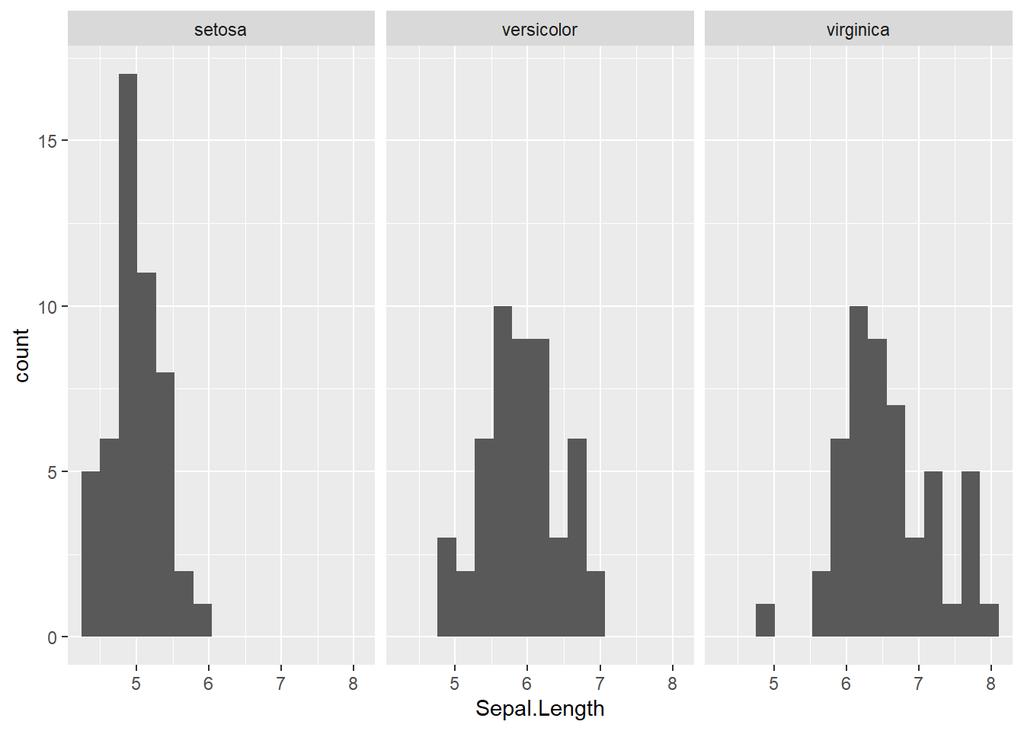

```r
iris %>%
  ggplot(mapping = aes(x = Sepal.Length)) +
  geom_histogram(bins = 15) +
  facet_wrap(~Species)
```

We can drill down even further within each subplot by grouping the histograms based on other variables in the dataset. For example, perhaps we would like to break up the `Sepal.Length` histograms based on if the `Sepal.Width` value is greater than the median `Sepal.Width` value. The result of this conditional test will be linked to the color of the histogram. Thus, we are adding an additional aesthetic to the graphic. The x-axis aesthetic was assigned within the parent `ggplot()` function, but we can also assign aesthetics within separate geom calls. The format is similar and any aesthetic not assigned within a geom will be inherited from the parent `ggplot()` call. The code chunk below shows how to break up the histograms within each `Species` level based on the conditional test. An important difference between the code chunk below with the previous code chunk is that the histogram is represented by the frequency polygon, `geom_freqpoly()`, rather than the conventional histogram. When overlaying multiple histograms within a plot, I prefer to use the frequency polygon because we only have to compare lines rather than filled in areas.

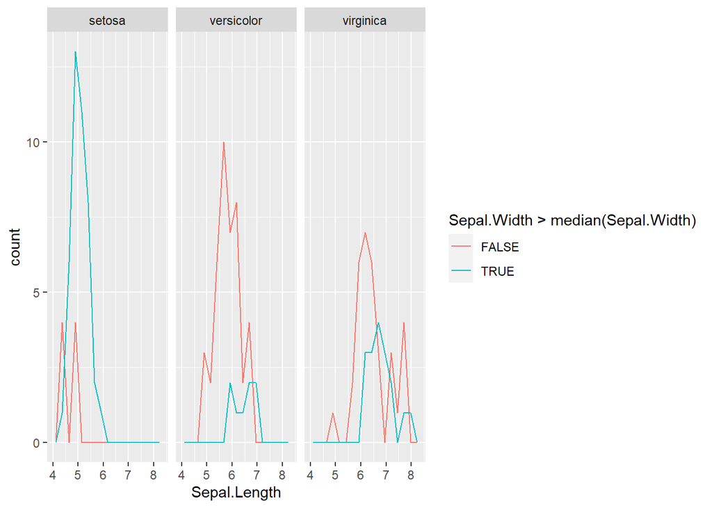

```r
iris %>%
  ggplot(mapping = aes(x = Sepal.Length)) +
  geom_freqpoly(bins = 15,
                mapping = aes(color = Sepal.Width > median(Sepal.Width))) +
  facet_wrap(~Species)
```

As shown above, `ggplot2` automatically creates the color legend with a label. The default position of that legend shrinks the overall plot area by a considerable amount. So let’s move the legend to the top of the graphic by modifying the `legend.position` argument to the `theme()` function:

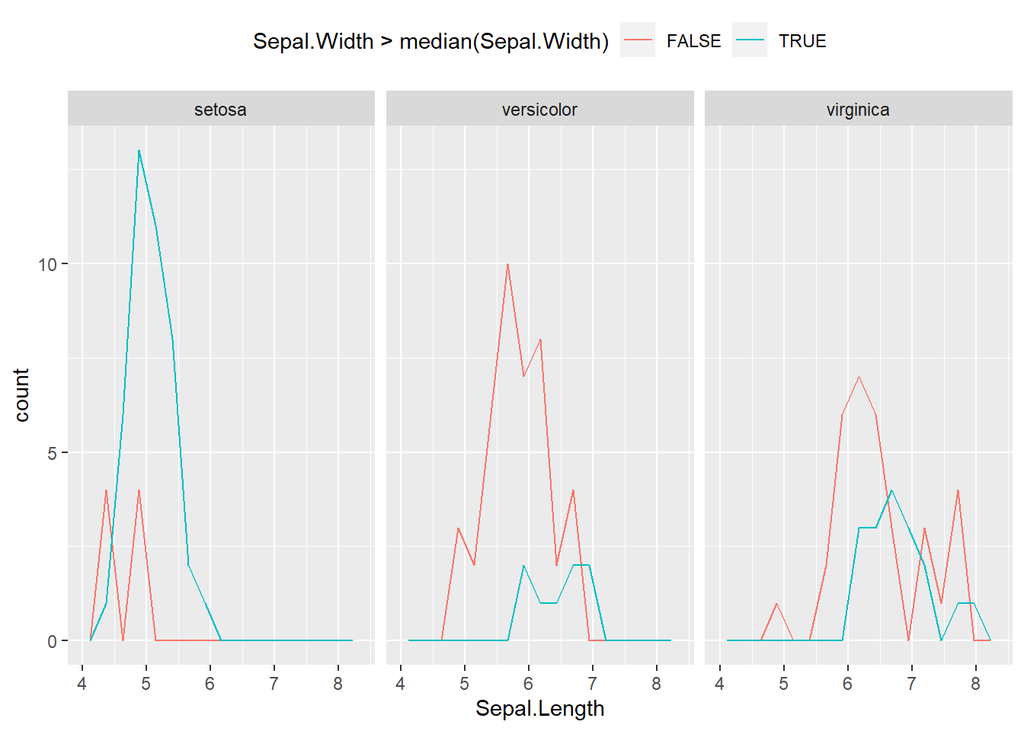

```r
iris %>%
  ggplot(mapping = aes(x = Sepal.Length)) +
  geom_freqpoly(bins = 15,
                mapping = aes(color = Sepal.Width > median(Sepal.Width))) +
  facet_wrap(~Species) +
  theme(legend.position = "top")
```

**Question: How many aesthetics are shown in the figure above?** We set the x-axis variable to `Sepal.Length`, we assigned the color of each histogram to a conditional test applied to `Sepal.Width`, and we assigned separate facets to `Species`. But how was the y-axis variable assigned?

The `geom_histogram()` and `geom_freqpoly()` geoms by default display the **count** or number of observations found within each bin on the y-axis. Thus, both geoms perform an operation behind the scenes and display the result as the y-axis aesthetic. That operation requires: breaking up the x-axis interval into the desired number of bins, calculating the number of observations within each bin, and assigning that number to the y-axis. To make it clear that separate observations are still “known” after performing the binning and counting operation, we will add a second geom to the graphic. Let’s put a tick mark along the x-axis at the exact location of the `Sepal.Length` value for each observation via the `geom_rug()` geom. As shown in the code chunk below, the new layer is added directly after the `geom_freqpoly()` call.

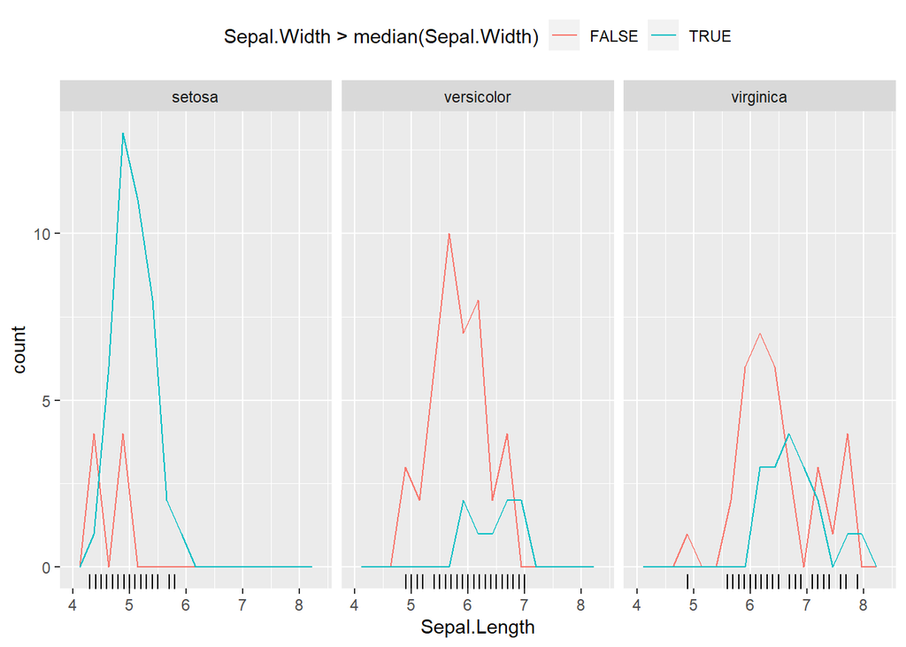

```r
iris %>%
  ggplot(mapping = aes(x = Sepal.Length)) +
  geom_freqpoly(bins = 15,
                mapping = aes(color = Sepal.Width > median(Sepal.Width))) +
  geom_rug() +
  facet_wrap(~Species) +
  theme(legend.position = "top")
```

In the above figure, the newly added tick marks are black. **Why is that the case?** How would you set the tick marks to have the same color scheme as the histograms within each facet?

It is important to note that by displaying the count as the y-axis aesthetic for histograms, it might be difficult to compare multiple histograms when the groups have vastly different number of observations. For example, the `"setosa"` species has a different number of observations based on whether `Sepal.Width` is above its median value. The same conclusion can be drawn based on the facet for the `"versicolor"` species. We can normalize the counts to remove the impact of the *sample size* and hopefully make the *distribution* comparisons more visually telling. We already discussed the “hidden” operation performed to create the histogram, but we can instruct `ggplot2` to perform additional operations or *statistical transformations*. We can override the default count y-aesthetic by calling the `stat()` function. To normalize we will use `stat(density)`. If you are not familiar with the density, that is ok. We will be discussing what that term means within this course!

In the code chunk below, we set the y-axis aesthetic within the `geom_freqpoly()` call to be the statistical transformation `stat(density)`. As shown in the resulting figure, the separate histograms within each facet are now of similar max height. Plotting the density for the `"setosa"` species instead of the count really makes the “spike” like behavior stand out for the histogram corresponding to `Sepal.Width` below its median.

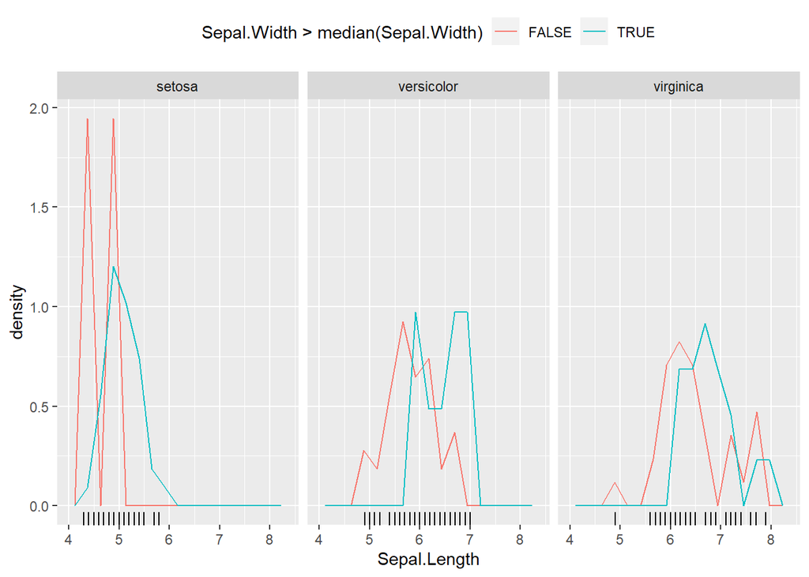

```r
iris %>%
  ggplot(mapping = aes(x = Sepal.Length)) +
  geom_freqpoly(bins = 15,
                mapping = aes(color = Sepal.Width > median(Sepal.Width),
                              y = stat(density))) +
  geom_rug() +
  facet_wrap(~Species) +
  theme(legend.position = "top")
```

A side-effect of using the density instead of the count as the y-axis though, was that the second and third facets have “empty” space in the upper half of the plots. The y-axis scale is dominated by the first facet. We can allow the separate facets to use different axis scalings by modifying the `scales` argument to the `facet_wrap()` call. The options are, `"free"`, `"free_x"`, and `"free_y"`. Selecting `"free"` allows both axes to float within each subplot, while choosing `"free_x"` fixes the y-axis across all facets with floating x-axis (and vice versa for `"free_y"`). Because we want to visually see if the histogram covers a different range for each species we will choose the `"free_y"` option. The syntax for making this change is shown in the code chunk below.

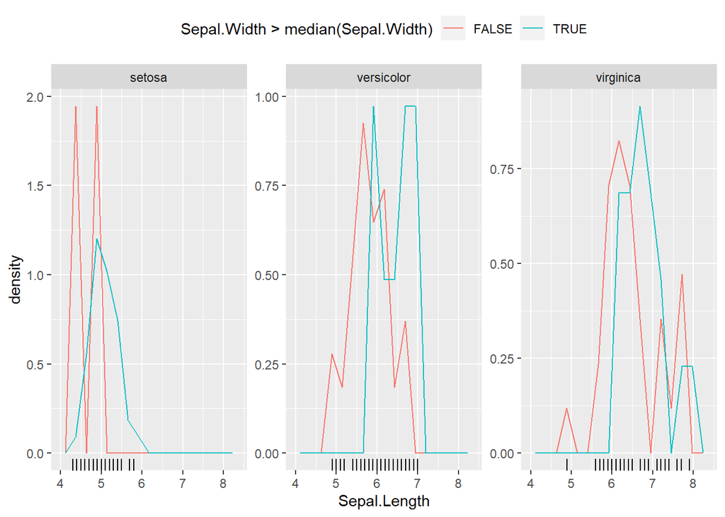

```r
iris %>%
  ggplot(mapping = aes(x = Sepal.Length)) +
  geom_freqpoly(bins = 15,
                mapping = aes(color = Sepal.Width > median(Sepal.Width),
                              y = stat(density))) +
  geom_rug() +
  facet_wrap(~Species, scales = "free_y") +
  theme(legend.position = "top")
```

Another cosmetic adjustment is that I usually turn off the y-axis text when I am displaying histograms across separate facets. I do this to save space within the plot window. The y-axis text is controlled by the `axis.text.y` argument within the `theme()` function. To turn the text off we will use the `element_blank()` function, as shown in the code chunk below.

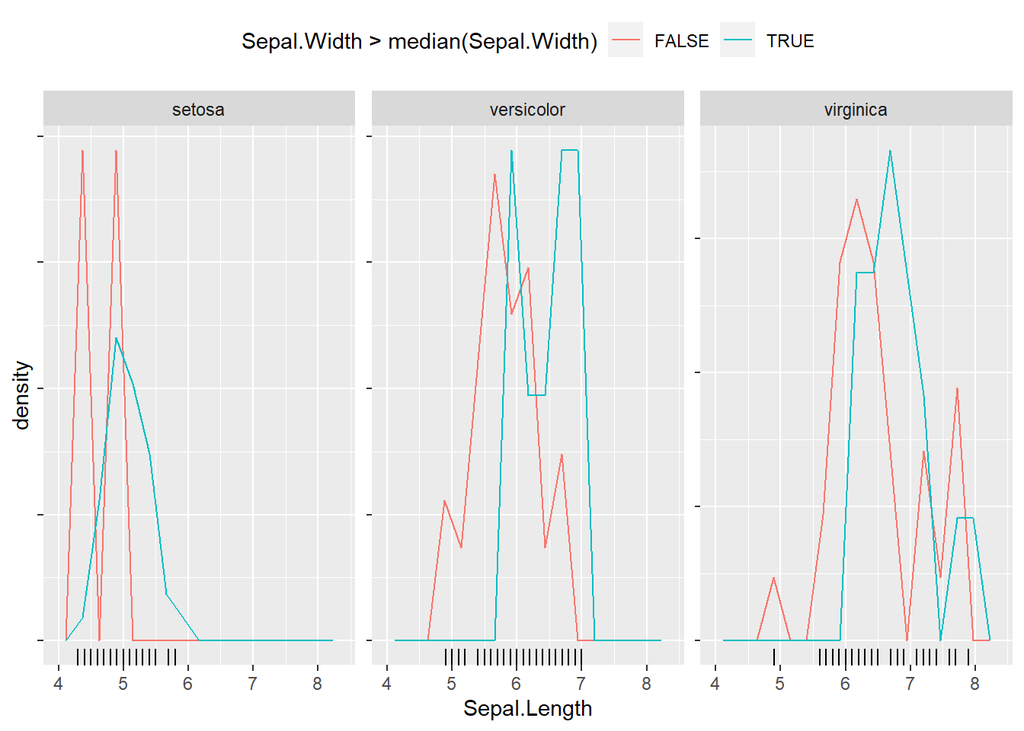

```r
iris %>%
  ggplot(mapping = aes(x = Sepal.Length)) +
  geom_freqpoly(bins = 15,
                mapping = aes(color = Sepal.Width > median(Sepal.Width),
                              y = stat(density))) +
  geom_rug() +
  facet_wrap(~Species, scales = "free_y") +
  theme(legend.position = "top",
        axis.text.y = element_blank())
```

Lastly, the default colors can sometimes be a little difficult to see. So let’s use a different color palette. `ggplot2` has many possible color scales. When comparing a few groups I typically use the brewer color palette with the function `scale_color_brewer()`. As shown in the code chunk below, place the scale function after the facet call:

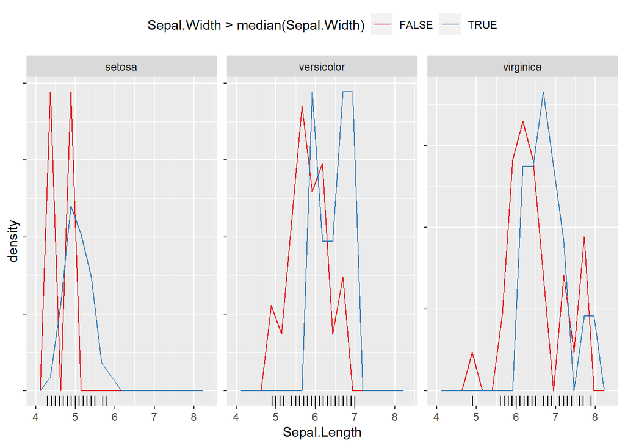

```r
iris %>%
  ggplot(mapping = aes(x = Sepal.Length)) +
  geom_freqpoly(bins = 15,
                mapping = aes(color = Sepal.Width > median(Sepal.Width),
                              y = stat(density))) +
  geom_rug() +
  facet_wrap(~Species, scales = "free_y") +
  scale_color_brewer(palette = "Set1") +
  theme(legend.position = "top",
        axis.text.y = element_blank())
```

By showing how to plot simple histograms, we have seen some of the major elements for building a `ggplot2` figure. We must specify our dataset and map the variables to the appropriate aesthetics. We must decide what type of geometric object we will use to visualize those aesthetics. We might have to perform statistical transformations, and we may need to decide how to break up the graphic into separate facets. We can modify how the aesthetics are displayed through `scale_` functions, and finally we can alter the overall appearance of the graphic with the `theme()` function. Each of these elements are discussed in more detail within the [R for Data Science](https://r4ds.had.co.nz/) book. For a list of all available geometric objects please see the `ggplot2` [RStudio cheatsheets](https://www.rstudio.com/resources/cheatsheets/).

#### themes

A quick note on themes. The default theme has a gray background and white grid lines. I like that look when I am interactively exploring a dataset, but I avoid the gray background when placing figures in presentations and reports. In those situations I prefer to use `theme_bw()` which turns the background white with gray grid lines, as shown below:

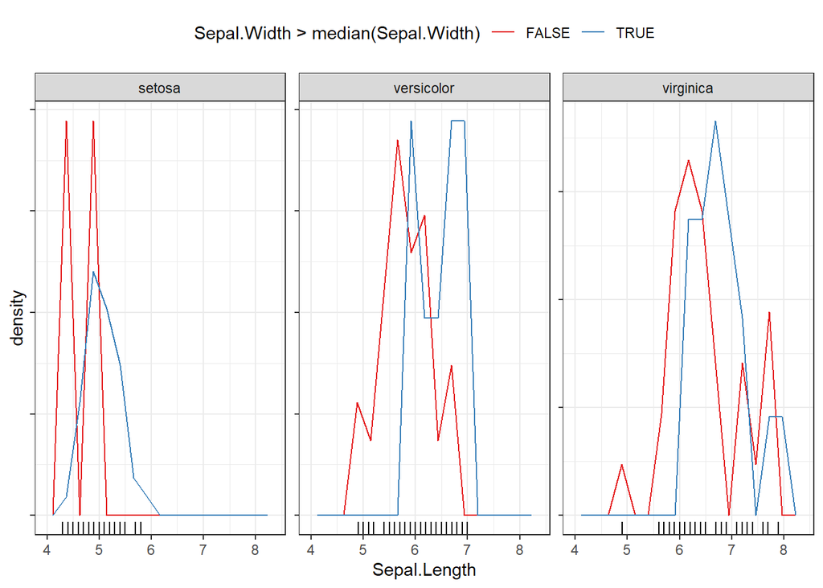

```r
iris %>%
  ggplot(mapping = aes(x = Sepal.Length)) +
  geom_freqpoly(bins = 15,
                mapping = aes(color = Sepal.Width > median(Sepal.Width),
                              y = stat(density))) +
  geom_rug() +
  facet_wrap(~Species, scales = "free_y") +
  scale_color_brewer(palette = "Set1") +
  theme_bw() +
  theme(legend.position = "top",
        axis.text.y = element_blank())
```

When visually comparing a few groups, sometimes I prefer to use a different color scale than the brewer scale shown previously. The `ggthemes` package includes a color blind safe color palette. To use it, we must first download and install `ggthemes`. You can run the code chunk below if you have not already installed `ggthemes`.

```r
install.packages("ggthemes")
```

The color blind safe option is the function `scale_color_colorblind()`. Rather than loading the `ggthemes` package with the `library()` call, we will access the function directly from the package with the `::` operator. I like to use this functionality when I want one or two functions from a package. This way, I do not have to load the complete package into the session. The syntax is: `<package>::<function>`. The code chunk below replaces the brewer color palette with the color blind safe palette from `ggthemes`:

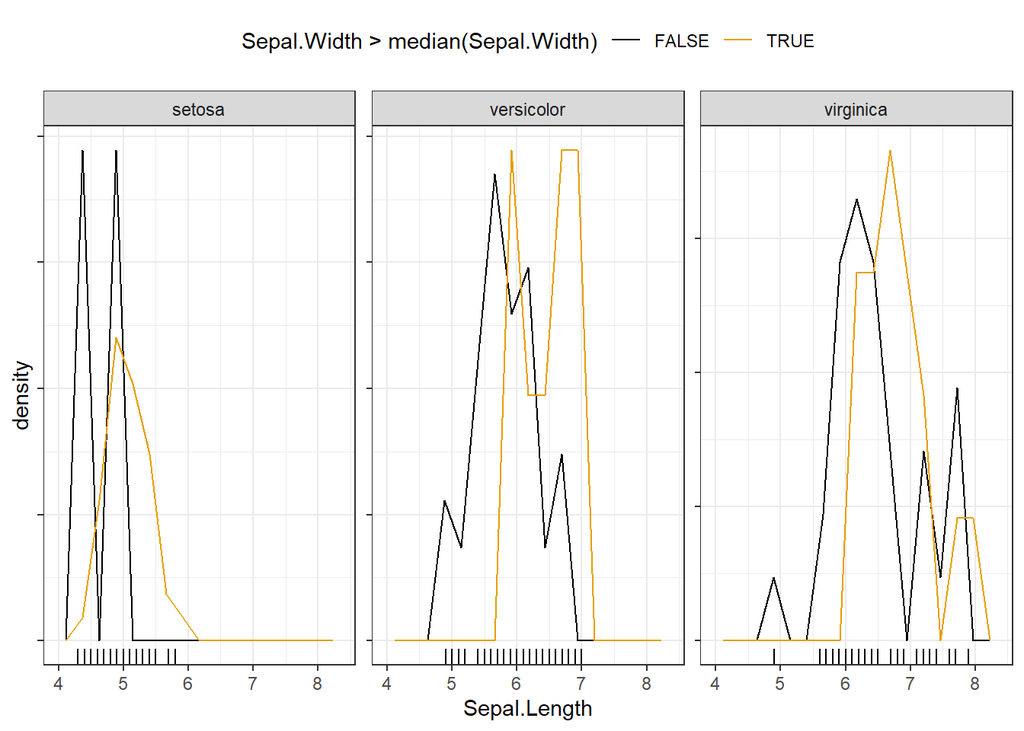

```r
iris %>%
  ggplot(mapping = aes(x = Sepal.Length)) +
  geom_freqpoly(bins = 15,
                mapping = aes(color = Sepal.Width > median(Sepal.Width),
                              y = stat(density))) +
  geom_rug() +
  facet_wrap(~Species, scales = "free_y") +
  ggthemes::scale_color_colorblind() +
  theme_bw() +
  theme(legend.position = "top",
        axis.text.y = element_blank())
```

Lastly, we can increase the line thickness of the frequency polygons by changing the `size` argument to the `geom_freqpoly()` function. We are not associating the `size` with a variable from the dataset. Thus, we will manually set the `size` **outside** the `aes()` function within `geom_freqpoly()`. The code chunk below raises the frequency polygon line size to 1.2.

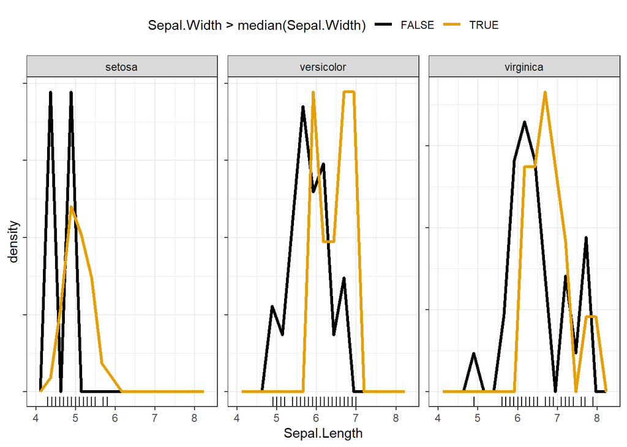

```r
iris %>%
  ggplot(mapping = aes(x = Sepal.Length)) +
  geom_freqpoly(bins = 15,
                mapping = aes(color = Sepal.Width > median(Sepal.Width),
                              y = stat(density)),
                size = 1.2) +
  geom_rug() +
  facet_wrap(~Species, scales = "free_y") +
  ggthemes::scale_color_colorblind() +
  theme_bw() +
  theme(legend.position = "top",
        axis.text.y = element_blank())
```

## Conclusion

This was just a short introduction to the `R` programming language and the `tidyverse`. There are many more topics to discuss and we will be doing so throughout the semester.